# Is there a correlation between covid-19 related sentiments and vaccine coverage?

20-June-2022

#### Group members: Ziyue Zhu (r0770748) & Linze Wu (r0817498)

#### Group number: 16

#### install libraries

```r
install.packages("formattable")
install.packages("tm")
install.packages("SnowballC")
install.packages("syuzhet")
install.packages("sentimentr")
install.packages("RColorBrewer")
install.packages("tidygeocoder")
install.packages("countrycode")
install.packages("tidytext")
install.packages("wordcloud")
install.packages("topicmodels")
install.packages("ggraph")
install.packages("rsample")
install.packages("caret")
install.packages("LiblineaR")
install.packages("pROC")
install.packages("mlbench")
install.packages("rpart")
install.packages("randomForest")
install.packages("e1071")
# Google trend
install.packages("gtrendsR")
install.packages("ggthemes")
```

```r
# plotting and pipeline
library(ggplot2)
library(dplyr)
library(tidyr)
library(stringr)
library(tidyverse)
library(formattable)

# Google trends
library(ggthemes)
library(gtrendsR)

# geo location
library(tidygeocoder)
library(base)
library(countrycode)

# text mining
library(tm)
library(SnowballC)
library(tidytext)

# sentiments analysis
library(syuzhet)
library(sentimentr)
library(wordcloud)
library(RColorBrewer)

# LDA
library(topicmodels)
library(ggraph)

# superised machine learning
library(e1071)
library(randomForest)
library(rpart)
library(mlbench)
library(rsample)
library(caret)
library(pROC)
```

## Overview

1. Problem Statement & Research Question
2. Data and Methods
3. Data Cleaning
4. Analysis
5. Results
6. Limitation
7. Conclusion
8. Elevator pitch

References

## 1. Problem Statement & Research Question

Around the world, a virus known as Covid-19 has been spreading since December 2019. During the outbreak of the pandemic, almost every country experienced this public health crisis. An antiviral vaccine is seen as an urgent and necessary method to combat the disease. However, anti-vaccination movements remain a threat even faced with the pandemic (Megget 2020). Bail (2016) discussed emotional contagion and interactive behavior on social media in the context of public health discussion. Following his discussion, To et al. (2021) provides an example identifying anti-vaccination tweets using machine learning methods, and Johnson et al. (2020) shed light on the competition between pro-and anti-vaccination on Twitter.

RQ: In this research, we aim to explore the sentiments and topics discussed in Covid-19 context, reflected by the worldwide tweets. More importantly, we want to link the sentiments with vaccine coverage and see if they are correlated. Our research question reads as follows: (1) do patterns exist in Covid-19 discussion? (2) is there a correlation between Covid-19 related sentiments and vaccination rate?

Before we dive into our analysis. We take a look at Google Trends using “Covid-19”, “corona”, “covid vaccination”, “work from home”, and “quarantine” as keywords. We extract the latest one month search counts, and we see that corona, quarantine, and work from home are most searched terms; while vaccination has little attention. Ideally, we should search for different terms related covid vaccination such as “covid vaccination side effects”, and so on.

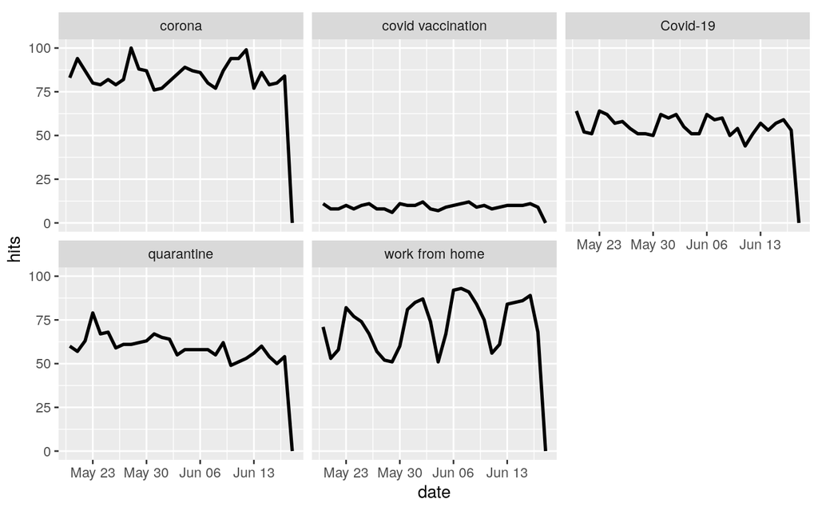

```r
search_terms <- c("Covid-19", "corona", "covid vaccination", "work from home", "quarantine")
gtrends(keyword = search_terms,
        geo = "US",
        time = "today 1-m") %>%
  .$interest_over_time %>%
  mutate_at("hits", ~ifelse(. == "<1", 0.5, .)) %>% # replace with 0.5
  mutate_at("hits", ~as.numeric(.)) %>% # convert to numeric
  ggplot(aes(x = date, y = hits)) +
  geom_line(colour = "black", size = 1) +
  facet_wrap(~keyword) -> plot

plot
```

## 2. Data and Methods

### 2.1 Data Description

There are two data sets we used in this analysis: (1) geo-tagged tweets related to covid-19 (2) Covid-19 cases and vaccination data set. We use geo-tagged tweets data set provided by IEEE Portal (Lamsal 2021), which contains IDs and sentiment scores of geo-tagged tweets related to the Covid-19 pandemic. Lamsal (2021) use 90+ different keywords and hashtags that are commonly used while referencing the pandemic in monitoring tweets, and the tweets created providing an exact location. Due to the Twitter’s content redistribution policy, only the tweet IDs are shared. We re-construct the dataset by hydrating these IDs using Hydrator (https://github.com/DocNow/hydrator). Since we will calculate our own scores, we remove the sentiment scores provided by Lamsal (2021). The variables of interest are “text”, “coordinates”, and “created time”. We hydrate the geo-twitter from Jan 2021 to May 2022, however, due to the limited computing power, we only select tweets in 2022 for analysis.

Covid-19 data are obtained from Our World in Data (https://ourworldindata.org/coronavirus) (Hannah Ritchie and Roser 2020), which contains worldwide daily information about confirmed cases, death, vaccination, and country characteristics such as population and expected life. The time window of this data frame starts from the first confirmed case of Covid-19, and the actual data we use are those overlap date and country with Tweets data.

The data sets we use are de-identified. All raw data are available in our Github repository (https://github.com/ziyue16/Big-Data-for-Social-Science-Project/tree/main/Data).

### 2.2 Methods (methodological design)

Our analysis is divided into two parts, unsupervised machine learning and supervised machine learning. In the unsupervised machine learning part, we conduct text mining. More specifically, we conduct Sentiment Analysis, Topics Modeling (LDA), and also explore Bigram Network. We aim to get the sentiment score to feed in the following supervised analysis, and see patterns of tweets. In supervised machine learning part, we test Linear Model, Decision Tree Regression, Random Forest Regression, and Support Vector Regression. We aim to select the best model and use the best model in predicting vaccination rate. Additionally, we explore whether sentiment score is important in the modeling (factor importance).

## 3. Data Cleaning

### 3.1 Data Pre-Processing

Time window: 2021-01~2022-06(present)

```r
# set your working folder here
# setwd("")
# load Tweets data set
Tweets <- read.csv("df.csv",encoding="UTF-8")
```

```r
# split coordinate
Tweets[c('Lon', 'Lat')] <- str_split_fixed(Tweets$coordinates, ',', 2)

# extract time
Tweets[c('Day_Week', 'Mon', 'Day', 'Time1', 'Time2', 'Year')] <- str_split_fixed(Tweets$created_at, ' ', 6)
Tweets[c('Hour', 'Minutes', 'Second')] <- str_split_fixed(Tweets$Time1, ':', 3)
Tweets$Date <- paste(Tweets$Year, Tweets$Mon, Tweets$Day)

# drop variables
Tweets <- select(Tweets,-c('Time1','Time2','Minutes','Second','coordinates','created_at'))
```

```r
# count by year and month
year_months <- Tweets %>%
  select(Year,Mon) %>%
  count(Year, Mon, sort = TRUE)

year_months <- Tweets %>%
  select(Year,Mon) %>%
  count(Year, Mon, sort = TRUE)

formattable(head(year_months, 12),
            col.names = c("Year", "Month", "Total of Tweets"),
            list(n = formatter("span",
                               style = n ~ style(
                                 display = "inline-block",
                                 direction = "rtl",
                                 "border-radius" = "8px",
                                 "padding-right" = "2px",
                                 "background-color"=csscolor("#1b7837"),
                                 width = percent(proportion(n)),
                                 "font-family" = "verdana",
                                 "font-size" = 10,
                                 color = csscolor("white")
                               ))))
```

We originally extract data from 2021 Jan to June 2022. The data set exceeds 64G when conducting text mining. Hence, we select year 2022 in the following analysis. The coordinates are provided in the data set, but we need “country” or “ios code” to merge into covid data set. Then we use reverse_geo() to recover country for year 2022. we run over 2hrs to get the location data. Once we get them, we save as the location in csv for later use. (We suggest not run these lines to save time)

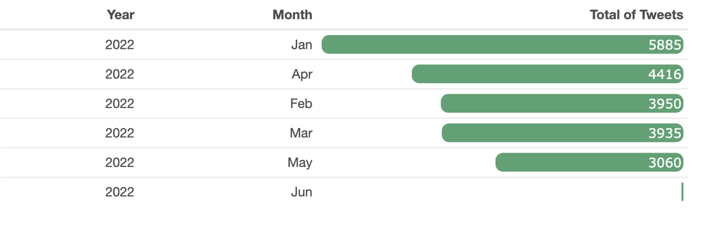

```r
Tweets <-Tweets[(Tweets$Year=="2022"),]
```

```r
# extract geo location
# we run over 2hrs to get the location data. Once we get them, we save as csv.
# We advise you do not run line 213 - 221
Geo2022 <- Tweets %>%
  reverse_geo(
    lat = Tweets$Lat,
    long = Tweets$Lon,
    method = "osm",
    full_results = TRUE
  ) %>%
  select(lat, long, country, country_code)
write.csv(Geo2022,"~/Geo2022.csv")

Geo<-read.csv("Geo2022.csv")
Geo$ios_code <- countrycode(Geo$country_code, "iso2c",'iso3c')

## merge geo-location
Tweets <- cbind(Tweets, Geo$ios_code, Geo$country)
```

### 3.2 Text Pre-Processing

Here we come to the text pre-processing section. Tweets texts are massed with URLs, mentions, hashtags, retweets, puntucations, and emojis. We build a clean_tweets() function to solve these problems Allen (2013). Then we load the text into a corpus and perform further cleaning such as remove English common stopwords and stemming. We manually check the original text and processed text, and we confirm that the texts have been cleaned.

```r
# Text cleaning
clean_tweets <- function(x) {
  x %>%
    # Remove URLs
    str_remove_all(" ?(f|ht)(tp)(s?)(://)(.*)[.|/](.*)") %>%
    # Remove mentions e.g. "@my_account"
    str_remove_all("@[[:alnum:]_]{4,}") %>%
    # Remove hashtags
    str_remove_all("#[[:alnum:]_]+") %>%
    # Replace "&" character reference with "and"
    str_replace_all("&amp;", "and") %>%
    # Remove puntucation, using a standard character class
    str_remove_all("[[:punct:]]") %>%
    # Remove "RT: " from beginning of retweets
    str_remove_all("^(RT|via):? ") %>%
    # Replace any newline characters with a space
    str_replace_all("\\\n", " ") %>%
    # Make everything lowercase
    str_to_lower() %>%
    # Remove any trailing white space around the text
    str_trim("both") %>%
    # Remove emoji
    str_remove_all("[^[:ascii:]]") %>%
    # Remove digits
    str_remove_all(" [[:digit:]]") %>%
    # Remove extra white spaces
    str_replace_all("\\s+", " ")
}

All_text <- Tweets$text
Tweets$cleaned_text <- All_text %>% clean_tweets
# ref: (Hicks , 2014, Stanton 2013)
```

```r
# load the data as a corpus
TextDoc <- VCorpus(VectorSource(Tweets$cleaned_text),
                   readerControl = list(reader = reader(VectorSource(Tweets$cleaned_text)),
                                        language = "en"))

# Remove English common stopwords
TextDoc <- tm_map(TextDoc, removeWords, stopwords("english"))

# Remove extra whitespace
TextDoc <- tm_map(TextDoc, stripWhitespace)

# Text stemming - which reduces words to their root form
TextDoc <- tm_map(TextDoc, stemDocument)

# Convert my corpus to data frame
text <- data.frame(text = sapply(TextDoc, as.character), stringsAsFactors = FALSE)
```

## 4. Analysis

### 4.1 Sentiments Analysis

Sentiment Analysis can help us understand the tone of text data, including positive or negative tones. By doing so, policymakers can formulate targeted regional development strategies based on the voice of their citizens during the pandemic.

In this part, we consider the distribution of basic emotions and averaged sentiment score for the Tweets.

#### 4.1.1 Primary Emotions Analysis

According to the NRC sentiment dictionary, English words are associated with two emotions (negative and positive), as well as eight basic emotions (fear, trust, anger, sadness, disgust, anticipation, joy, and surprise).

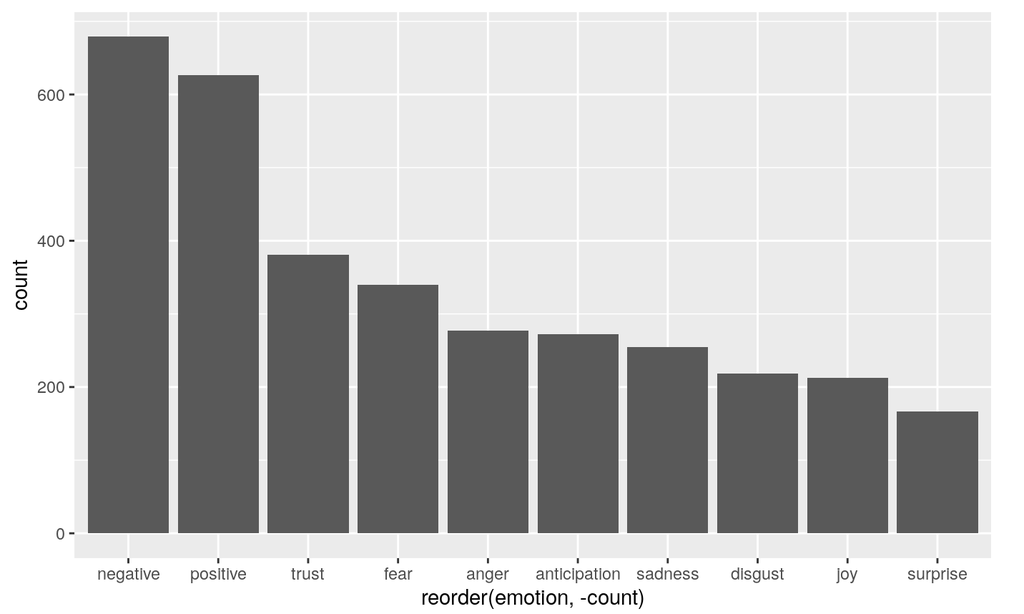

```r
# the NRC sentiment dictionary
text_character<-as.character(text)
emotions<-get_nrc_sentiment(text_character)
emo_bar<-colSums(emotions)
emo_sum<-data.frame(count=emo_bar,emotion=names(emo_bar))

# Barplot
ggplot(emo_sum,aes(x=reorder(emotion, -count),y=count))+geom_bar(stat='identity')
```

According to the bing sentiment dictionary, the Tweets are categorized as positive or negative.

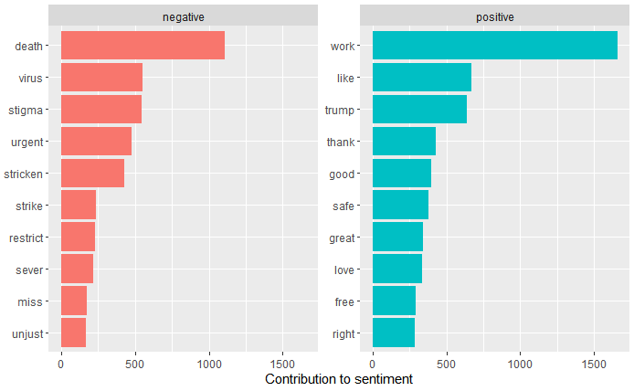

```r
# the bing sentiment dictionary
wordcloud<-text %>% unnest_tokens(output=word,input = text) %>%
  inner_join(get_sentiments("bing"))%>%
  count(word,sentiment,sort=TRUE)

# select top 10 words by sentiment
bing_10 <- wordcloud %>%
  group_by(sentiment) %>%
  slice_max(order_by = n, n = 10) %>%
  ungroup() %>%
  mutate(word = reorder(word, n))

# create a barplot showing contribution of words to sentiment
bing_10 %>%
  ggplot(aes(word, n, fill = sentiment)) +
  geom_col(show.legend = FALSE) +
  facet_wrap(~sentiment, scales = "free_y") +
  labs(y = "Contribution to sentiment", x = NULL) +
  coord_flip()
```

Death, virus, stigma and urgent are some of the most negative words, while work, like, trump (an interesting classification supported by bing sentiment dictionary), and thank are some of the most positive.

#### 4.1.2 Visualization of Positive-Negative Wordcloud

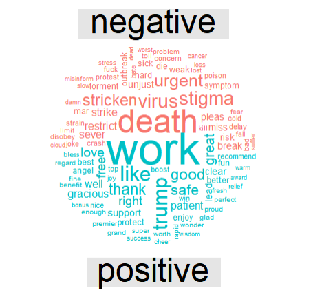

```r
# Generate the word cloud
# Positive and negative words
text %>% unnest_tokens(output=word,input = text) %>%
  inner_join(get_sentiments("bing")) %>%
  count(word,sentiment,sort=TRUE)%>%
  reshape2::acast(word ~ sentiment, value.var = "n", fill = 0) %>%
  comparison.cloud(colors=c("#F8766D", "#00BFC4"), max.words=100)
```

#### 4.1.3 Averaged Sentiment Score for given Tweets

The average sentiment scores for each tweets are calculated and save for supervised machine learning.

```r
text$ID <- seq_along(text[,1])
sent<-sentiment_by(text$text, by=list(text$ID))
write.csv(sent,"~/sent.csv")
```

### 4.2 Latent Dirichlet Allocation (LDA)

LDA is an unsupervised machine learning method to infer information about the topic distribution of documents. It automates the relationship between topics, words, and documents. In this part, we specify four topics and calculate the most informative words with each topic. As shown in the figure below, the first topic is related information about Covid-19, The second topic is more about the religion. The third topic is about the policy, and the last one is much closer to daily life.

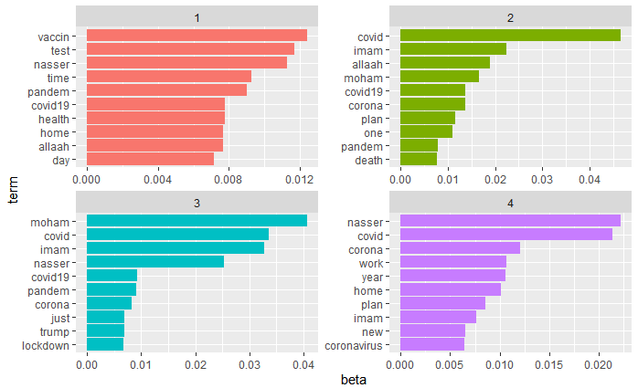

```r
# LDA with 4 topics
DTM <- DocumentTermMatrix(TextDoc)
unique_indexes <- unique(DTM$i)
DTM <- DTM[unique_indexes,]

# A LDA_VEM topic model with 4 topics.
ap_lda <- LDA(DTM, k = 4, control = list(seed = 1234))

# Word-topic probabilities
ap_topics <- tidy(ap_lda, matrix = "beta")
ap_top_terms <- ap_topics %>%
  group_by(topic) %>%
  slice_max(beta, n = 10) %>%
  ungroup() %>%
  arrange(topic, -beta)
# The terms that are most common within each topic
ap_top_terms %>%
  mutate(term = reorder_within(term, beta, topic)) %>%
  ggplot(aes(beta, term, fill = factor(topic))) +
  geom_col(show.legend = FALSE) +
  facet_wrap(~ topic, scales = "free") +
  scale_y_reordered()
```

### 4.3 Bigram Network

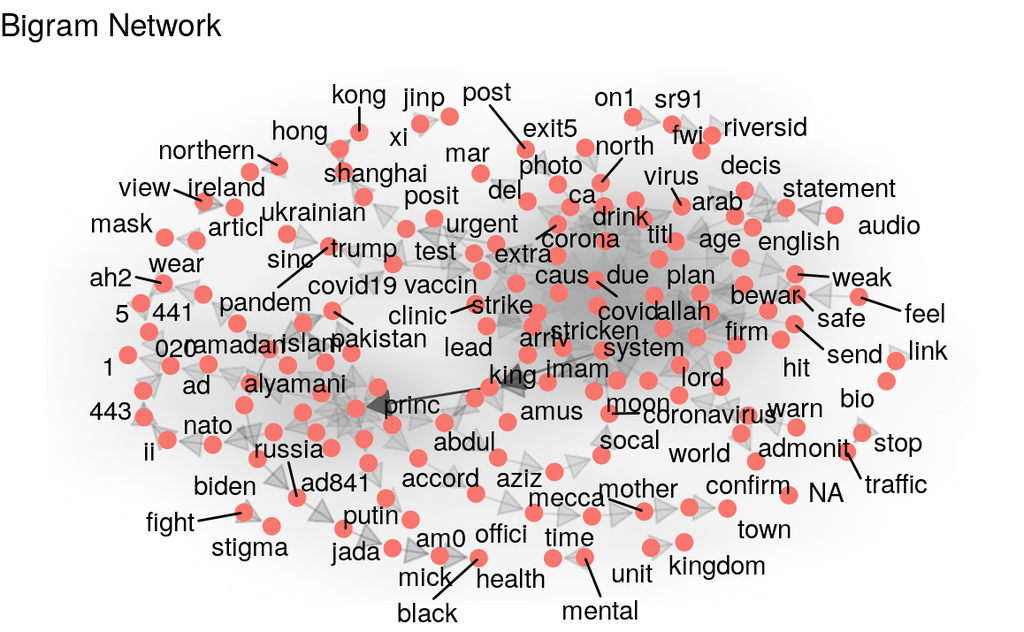

```r
# Bigrams
Bigrams<-text %>%
  unnest_tokens(word, text, token = "ngrams", n = 2) %>%
  separate(word, c("word1", "word2"), sep = " ") %>%
  filter(!word1 %in% stop_words$word) %>%
  filter(!word2 %in% stop_words$word) %>%
  unite(word,word1, word2, sep = " ") %>%
  count(word, sort = TRUE)
head(Bigrams)

# Visualize Networks of Bigrams
bigrams_network <- Bigrams %>%
  separate(word, c("word1", "word2"), sep=" ") %>%
  filter(n>100)

set.seed(2022)

arrows <- grid::arrow(type="closed", length=unit(0.15, "inches"))

ggraph(bigrams_network, layout="fr") +
  geom_edge_link(aes(edge_alpha=n), show.legend = F, arrow=arrows, end_cap=circle(0.07,'inches')) +
  geom_edge_density(aes(fill = n)) +
  geom_node_point(color="#F8766D", size=3) +
  geom_node_text(aes(label=name), repel=T) +
  theme_void() +
  labs(title="Bigram Network")
```

### 4.4 Initial Linear Regression

```r
# load data
covid_data <- read.csv("~/owid-covid-data.csv")
summary(covid_data)

Tweets_score <- read.csv("~/sent.csv")
Tweets_score <- Tweets_score[-c(21252),]

Tweets_all <- cbind(Tweets, Tweets_score)

Tweets_all <- select(Tweets_all, c('Day', 'Year', 'Mon', 'Geo$ios_code', 'ave_sentiment'))

Tweets_reg <- Tweets_all %>%
  group_by(Day, Year, Mon, Geo$ios_code) %>%
  summarise_at(vars(ave_sentiment), list(avg_sent = mean))

Tweets_reg["Mon"][Tweets_reg["Mon"] == "Jan"] <- "01"
Tweets_reg["Mon"][Tweets_reg["Mon"] == "Feb"] <- "02"
Tweets_reg["Mon"][Tweets_reg["Mon"] == "Mar"] <- "03"
Tweets_reg["Mon"][Tweets_reg["Mon"] == "Apr"] <- "04"
Tweets_reg["Mon"][Tweets_reg["Mon"] == "May"] <- "05"
Tweets_reg["Mon"][Tweets_reg["Mon"] == "Jun"] <- "06"

Tweets_reg["iso_code"] <- Tweets_reg["Geo$ios_code"]

Tweets_reg<-Tweets_reg[!(Tweets_reg$Mon=="06"),]
```

```r
# select related variables
covid_selected <- select(covid_data, c("iso_code", "location", "date", "total_cases", "total_deaths",
                                   "reproduction_rate", "icu_patients", "hosp_patients", "total_tests",
                                   "people_vaccinated", "people_fully_vaccinated", "stringency_index",
                                   "population", "population_density", "median_age", "gdp_per_capita",
                                   "extreme_poverty", "cardiovasc_death_rate", "diabetes_prevalence",
                                   "female_smokers", "male_smokers", "handwashing_facilities",
                                   "hospital_beds_per_thousand", "life_expectancy", "human_development_index"))

covid_selected[c('Year', 'Mon', 'Day')] <- str_split_fixed(covid_selected$date, '-', 3)

covid_selected$vacc_rate <- covid_selected$people_vaccinated / covid_selected$population
covid_selected$full_vacc_rate <- covid_selected$people_fully_vaccinated / covid_selected$population
covid_selected$country <- as.factor(covid_selected$location)

covid_selected <- merge(covid_selected, Tweets_reg, by=c('Day', 'Year', 'Mon', 'iso_code'))

summary(covid_selected)
```

```r
## Initial linear regression
model1 <- lm(formula = 'vacc_rate ~ country + total_cases + total_deaths + reproduction_rate + icu_patients + hosp_patients + total_tests + stringency_index + avg_sent', data = covid_selected)
summary(model1)
# should drop total death

model2 <- lm(formula = 'vacc_rate ~ population_density + median_age + gdp_per_capita + extreme_poverty + cardiovasc_death_rate + diabetes_prevalence + female_smokers +  male_smokers + handwashing_facilities + hospital_beds_per_thousand + life_expectancy + human_development_index', data = covid_selected)
summary(model2)
# should drop median_age and cardiovasc_death_rate

# final variable for modeling
summary(covid_selected)
covid_final <- select(covid_selected, -c('total_deaths','population','median_age','cardiovasc_death_rate'))

# remove missing values
covid_final <- covid_final[complete.cases(covid_final[,c("vacc_rate")]),]

# due to the amount of missing values, we drop some columns
summary(covid_final)
covid_final <- select(covid_final, -c('icu_patients','hosp_patients','total_tests','people_vaccinated',
                                      'people_fully_vaccinated', 'extreme_poverty', 'female_smokers',
                                      'diabetes_prevalence', 'male_smokers', 'handwashing_facilities',
                                      'hospital_beds_per_thousand','full_vacc_rate','human_development_index',
                                      'Geo$ios_code'))


covid_final <- covid_final[rowSums(is.na(covid_final)) == 0, ]

#covid_final[c('Year', 'Month', 'Day')] <- str_split_fixed(covid_final$date, '-', 3)

summary(covid_final)
```

```r
# check balanced
covid_final %>% group_by(date) %>% summarise(vacc_rate = n())
covid_final %>% count(country)
```

### 4.5 Supervised Machine Learning

Since vaccination rate is a continuous variable, we use regression techniques for prediction. More specifically, we use linear regression, decision tree regression, random forest regression, and support vector regression. The metric to evaluate these models is Mean Square Errors (MSE), which is presented in section 4.5.5. The following modeling follows a standard machine learning pipeline: split train, validation and test data, model and obtain metrics, select the best model. The details of each techniques are omitted here.

```r
# split the set
set.seed(6191231)

#initial_split creates a single binary split of the data into a training set and testing set
model_data <- select(covid_final, -c('iso_code', 'location', 'date', 'Day'))

split <- initial_split(model_data, prop = .7)
split

alltrain <- training(split)
dim(alltrain)

testdata <- testing(split)
dim(testdata)

# further split validation set
split2 <- initial_split(alltrain, prop = .7)
traindata <- training(split2)
dim(traindata)

valdata <- testing(split2)
dim(valdata)

X_alltrain <- select(alltrain, c('total_cases', 'reproduction_rate', 'stringency_index', 'population_density',
                               'gdp_per_capita','life_expectancy', 'country', 'Year','Mon','avg_sent'))
y_alltrain <- alltrain$vacc_rate

X_train <- select(traindata, c('total_cases', 'reproduction_rate', 'stringency_index', 'population_density',
                               'gdp_per_capita','life_expectancy', 'country','Mon','avg_sent'))
y_train <- traindata$vacc_rate

X_val <- select(valdata, c('total_cases', 'reproduction_rate', 'stringency_index', 'population_density',
                            'gdp_per_capita','life_expectancy', 'country', 'Mon','avg_sent'))
y_val <- valdata$vacc_rate

X_test <- select(testdata, c('total_cases', 'reproduction_rate', 'stringency_index', 'population_density',
                            'gdp_per_capita','life_expectancy', 'country', 'Mon','avg_sent'))
y_test <- testdata$vacc_rate
```

#### 4.5.1 Linear Regression

```r
### Linear Regression
linear_fit <- lm(y_train ~ total_cases + reproduction_rate + stringency_index + population_density +
                   gdp_per_capita + life_expectancy + Mon + avg_sent, data=traindata)
summary(linear_fit)
modelResiduals <- as.data.frame(residuals(linear_fit))

ggplot(modelResiduals, aes(residuals(linear_fit))) +
  geom_histogram(fill='deepskyblue', color='black')

linear_preds <- predict(linear_fit, valdata)

modelEval <- cbind(valdata$vacc_rate, linear_preds)
colnames(modelEval) <- c('Actual', 'Predicted')
modelEval <- as.data.frame(modelEval)

mse <- mean((modelEval$Actual - modelEval$Predicted)^2)
rmse <- sqrt(mse)
modelEval
mse
# 0.006278596
```

#### 4.5.2 Decision Tree Regression

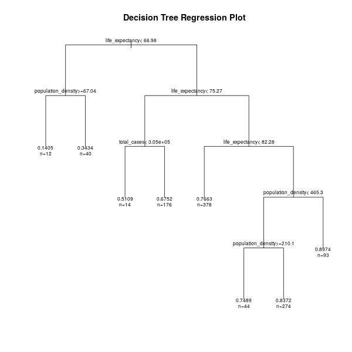

```r
### Decision Tree Regression
DT_fit <- rpart(y_train ~ total_cases + reproduction_rate + stringency_index + population_density +
                  gdp_per_capita + life_expectancy + Mon + avg_sent, data=traindata, method = "anova")

# Output to be present as PNG file
png(file = "decTreeGFG.png", width = 600,
    height = 600)

# Plot
plot(DT_fit, uniform = TRUE,
     main = "Decision Tree Regression Plot")
text(DT_fit, use.n = TRUE, cex = .7)
# ref: https://www.geeksforgeeks.org/decision-tree-for-regression-in-r-programming/
# Saving the file
dev.off()

# Print model
print(DT_fit)

# Prediction
cat("Predicted value:\n")
DecisionTree_preds <- predict(DT_fit, X_val, method = "anova")

modelEval2 <- cbind(valdata$vacc_rate, DecisionTree_preds)
colnames(modelEval2) <- c('Actual', 'Predicted')
modelEval2 <- as.data.frame(modelEval2)

mse2 <- mean((modelEval2$Actual - modelEval2$Predicted)^2)
rmse2 <- sqrt(mse2)
modelEval2
mse2
# 0.003039086
```

#### 4.5.3 Random Forest Regression

```r
### Random Forest
RF_fit <- randomForest(y_train ~ total_cases + reproduction_rate + stringency_index + population_density +
                         gdp_per_capita + life_expectancy + Mon + avg_sent, data=traindata,
                            keep.forest=TRUE, importance=TRUE, type= "regression")

RF_fit

# Prediction
RF_preds <- predict(RF_fit, X_val, type = 'response')
modelEval3 <- cbind(valdata$vacc_rate, RF_preds)
colnames(modelEval3) <- c('Actual', 'Predicted')
modelEval3 <- as.data.frame(modelEval3)

mse3 <- mean((modelEval3$Actual - modelEval3$Predicted)^2)
rmse3 <- sqrt(mse3)
modelEval3
mse3
# 0.0009473681
# seems to be the best model
```

#### 4.5.4 Support Vector Regression

```r
### Support Vector Regression
SVR_fit <- svm(y_train ~ total_cases + reproduction_rate + stringency_index + population_density +
                 gdp_per_capita + life_expectancy + Mon + avg_sent, data=traindata)

SVR_fit

# prediction
SVR_preds <- predict(SVR_fit, X_val)
modelEval4 <- cbind(valdata$vacc_rate, SVR_preds)
colnames(modelEval4) <- c('Actual', 'Predicted')
modelEval4 <- as.data.frame(modelEval4)

mse4 <- mean((modelEval4$Actual - modelEval4$Predicted)^2)
rmse4 <- sqrt(mse4)
modelEval4
mse4
# 0.004452095
```

#### 4.5.5 Models comparsion

The MSEs for evaluate the models are presented in the table below. We can see that Random Forest Regression is our best model.

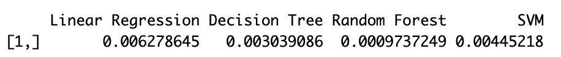

```r
## metrics comparsion
Comparsion <- cbind(mse, mse2, mse3, mse4)
colnames(Comparsion) <- c('Linear Regression', 'Decision Tree', 'Random Forest', 'SVM')
Comparsion
## Random forest is our best model
```

#### 4.5.6 Factor Importance

After obtaining the best model, we can safely run the model again on the whole training set (include validation set) and get our final parameters. Back to our research question, we perform factor importance analysis and see if sentiment scores present higher weights. However, “avg_sent”, which represents average sentiment scores presents the lowest importance in this model. We can conclude that average sentiment scores do not highly correlated with covid vaccination rate.

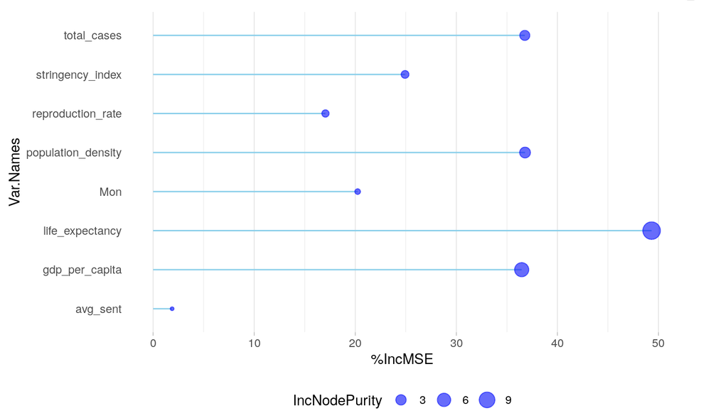

```r
# Run on the whole trainset and see factor importance
RF_final <- randomForest(y_alltrain ~ total_cases + reproduction_rate + stringency_index + population_density +
                           gdp_per_capita + life_expectancy + Mon + avg_sent, data=alltrain,
                         keep.forest=TRUE, importance=TRUE, type= "regression")

### Visualize variable importance
ImpData <- as.data.frame(importance(RF_final))
ImpData$Var.Names <- row.names(ImpData)

ggplot(ImpData, aes(x=Var.Names, y=`%IncMSE`)) +
  geom_segment( aes(x=Var.Names, xend=Var.Names, y=0, yend=`%IncMSE`), color="skyblue") +
  geom_point(aes(size = IncNodePurity), color="blue", alpha=0.6) +
  theme_light() +
  coord_flip() +
  theme(
    legend.position="bottom",
    panel.grid.major.y = element_blank(),
    panel.border = element_blank(),
    axis.ticks.y = element_blank()
  )
```

#### 4.5.7 Prediction on test set

```r
RF_preds_final <- predict(RF_final, X_test, type = 'response')
modelEval_final <- cbind(testdata$vacc_rate, RF_preds_final)
colnames(modelEval_final) <- c('Actual', 'Predicted')
modelEval_final <- as.data.frame(modelEval_final)

mse_final <- mean((modelEval_final$Actual - modelEval_final$Predicted)^2)
rmse_final <- sqrt(mse_final)
modelEval_final
mse_final
# 0.0007269366
```

## 5. Results

The unsupervised machine learning analysis answers our first research question (do patterns exist in Covid-19 discussion?). Overall, the Tweets show slightly more negative sentiments than positive sentiments. After LDA modeling, we discover all abstract topics that are more or less related to Muslims. The difference between these topics is the political aspect and daily life aspect. Furthermore, Bigrams Networks provides information about the link between COVID-19 and politics. The results of factor importance from Random Forest Regression yield the answer to our second research question (is there a correlation between Covid-19 related sentiments and vaccination rate?). The average sentiment scores shows little correlation with vaccination rate.

## 6. Limitation

There are three main limitations in our analysis:

1. the volume of the data: due to our limited computing power, we are not able to conduct the analysis we depicted before (using data from 2021 Jan). And limited number of observations could induce imbalanced data sets, for example, small countries could have no tweets in our selected time window.
2. context of the text: we did not consider the background that produces the text when analyzing. A lot of pre-processing or post-processing is required to perform the context based analysis, for example, remove words like “Covid-19”. Additionally, how to pre-or post-process data to capture contextual bits that help analyze sentiment is not straightforward. Positive emotions can turn into negative emotions when literal meanings are different from intended meanings, and negative emotions can turn into positive emotions when literal meanings are different from intended meanings. However, detecting sarcasm or sarcasm requires extensive analysis of the context in which the text is produced, making it difficult to detect automatically.
3. Twitter bias: in our analysis, we simple use average sentiment generated by tweets to present the country sentiment. However, twitter users cannot represent population and the estimates should be adjusted accordingly.

## 7. Conclusion

In this report, we use geo-tagged twitter data to explore the text patterns in Covid-19 related tweets and the sentiments related. Further, we performed regression to examine whether Covid-19 related sentiments correlates a country’s vaccination rate. We find that tweets reveal slightly more negative sentiments than positive sentiments, and we identify four topics via LDA modeling. Unfortunately, the average sentiment scores shows little correlation with vaccination rate through supervised machine learning. We have discussed several limitations in our analysis and further investigation is needed. First, Twitter bias should be adjusted in all research using Twitter data; second, robustness check or sensitive analysis should be performed to validate our results; third, more sophisticated text mining techniques should be use to capture the contextual meaning.

## 8. Elevator pitch

We propose a framework which links the Tweets context with Covid-19 vaccination rate via sentiments evaluated by the text. Both text mining and supervised machine learning regression are performed in our analysis in a responsible way. Although we find little correlation between sentiments and vaccination rate, we present the patterns inherent Covid-19 related tweets.

## References

Allen, Tasha R. AND Di Pietro, Heidi G. AND Stanton. 2013. “Social Media Release Increases Dissemination of Original Articles in the Clinical Pain Sciences.” *PLOS ONE* 8 (7): 1–6. https://doi.org/10.1371/journal.pone.0068914.

Bail, Christopher A. 2016. “Emotional Feedback and the Viral Spread of Social Media Messages about Autism Spectrum Disorders.” *American Journal of Public Health* 106 (7): 1173–80.

Hannah Ritchie, Lucas Rodés-Guirao, Edouard Mathieu, and Max Roser. 2020. “Coronavirus Pandemic (COVID-19).” *Our World in Data*.

Hicks, Amanda, William R Hogan, Michael Rutherford, Bradley Malin, Mengjun Xie, Christiane Fellbaum, Zhijun Yin, Daniel Fabbri, Josh Hanna, and Jiang Bian. 2015. “Mining Twitter as a First Step Toward Assessing the Adequacy of Gender Identification Terms on Intake Forms.” *AMIA ... Annual Symposium Proceedings. AMIA Symposium* 2015: 611–20. https://europepmc.org/articles/PMC4765681.

Johnson, Neil F, Nicolas Velásquez, Nicholas Johnson Restrepo, Rhys Leahy, Nicholas Gabriel, Sara El Oud, Minzhang Zheng, Pedro Manrique, Stefan Wuchty, and Yonatan Lupu. 2020. “The Online Competition Between Pro-and Anti-Vaccination Views.” *Nature* 582 (7811): 230–33.

Lamsal, Rabindra. 2021. “Design and Analysis of a Large-Scale COVID-19 Tweets Dataset.” *Applied Intelligence* 51 (5): 2790–2804.

Megget, Katrina. 2020. “Even Covid-19 Can’t Kill the Anti-Vaccination Movement.” *BMJ* 369.

To, Quyen G, Kien G To, Van-Anh N Huynh, Nhung TQ Nguyen, Diep TN Ngo, Stephanie J Alley, Anh NQ Tran, et al. 2021. “Applying Machine Learning to Identify Anti-Vaccination Tweets During the COVID-19 Pandemic.” *International Journal of Environmental Research and Public Health* 18 (8): 4069.